# Predict Dumbbell Biceps Curl Performance

The goal of the project is to predict the manner of doing the exercise and thus we can quantify how well people do it. Six young health participants were asked to perform one set of 10 repetitions of the Unilateral Dumbbell Biceps Curl in five different fashions: exactly according to the specification (Class A), throwing the elbows to the front (Class B), lifting the dumbbell only halfway (Class C), lowering the dumbbell only halfway (Class D) and throwing the hips to the front (Class E). The traning and testing datasets are from [Groupware@LES](http://groupware.les.inf.puc-rio.br/har).

## Load library and set the seed

```r
library(caret); library(corrplot)
set.seed(321)
```

## Downloading Data files and load data into R

```r
## Create training and testing dataset URL

fileURL.train <- "https://d396qusza40orc.cloudfront.net/predmachlearn/pml-training.csv"
fileURL.test <- "https://d396qusza40orc.cloudfront.net/predmachlearn/pml-testing.csv"

## Create Downloads directory if not exists

if (!file.exists("Downloads")) {
    dir.create("Downloads")
}

## Download the datasets

temp.train <- "~/Downloads/pml-training.csv"
download.file(fileURL.train, temp.train, method="curl")
temp.test <- "~/Downloads/pml-testing.csv"
download.file(fileURL.test, temp.test, method="curl")

## Load the training dataset

temp = read.csv("~/Downloads/pml-training.csv",
                header = TRUE, na.string = c("", "NA", "NULL", "#DIV/0!"))
```

## Preprocessing the data

Remove variables that have many NA values.

```r
temp = temp[, (colSums(is.na(temp)) == 0)]
```

Filter out the incomplete cases and remove the irrelevant variables: X, user_name, raw_timestamp_part_1, raw_timestamp_part_2, cvtd_timestamp, new_window, num_window.

```r
temptrain = temp[complete.cases(temp), -c(1, 2, 3, 4, 5, 6, 7)]
```

## Data Splitting

The original training dataset is splitted into model training and testing datasets. The are 14718 and 4904 observations respectively.

```r
inTrain = createDataPartition(y = temptrain$classe, p = 0.75, list = FALSE)
training = temptrain[inTrain,]
testing = temptrain[-inTrain,]
dim(training); dim(testing)
```

```
## [1] 14718    53
```

```
## [1] 4904   53
```

## Remove High Correlation (over 0.8) Variables

From the correlation plot, we can identify several high correlated variables. Thirteen variables in the training dataset are removed to reduce the pair-wise correlations. The correlation cutoff is 0.8. Thirty nine predictors are used to build the prediction.

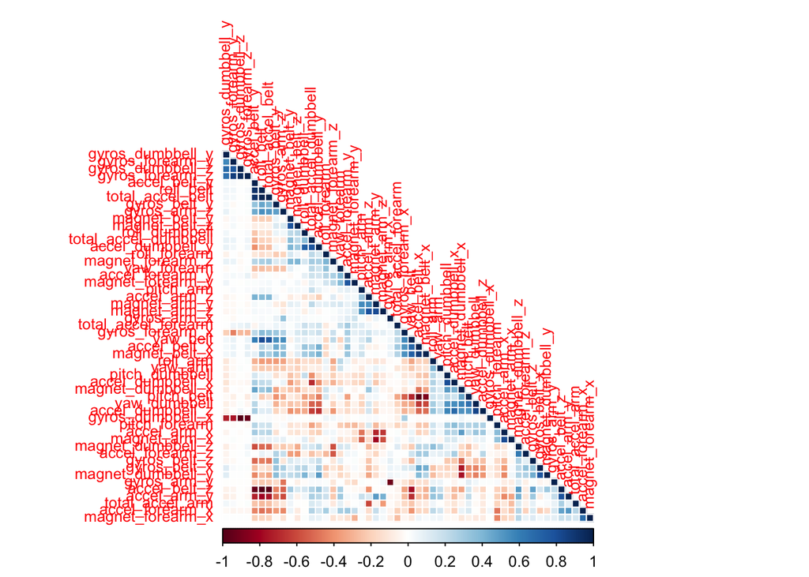

```r
## Column 53 is classe and is not included in the correlation matrix.

corrMatrix = cor(training[, -53])
corrplot(corrMatrix, order = "hclust", method="color", type = "lower", tl.cex = 0.8)
```

```r
highCorr = findCorrelation(corrMatrix, cutoff = 0.8)
newtraining = training[,-highCorr]
dim(newtraining)
```

```
## [1] 14718    40
```

## Building Prediction

The training dataset has 14718 observations of 39 predictors. Random forest is used to create the model because it is the top performance algorithm for classifier. The accuracy on traing dataset is 0.987. The long training hour (over 10 hours) is a major disadvantge.

```r
modrf <- train(newtraining$classe ~ ., data = newtraining, method = "rf", prox = TRUE)
modrf
```

```
## Random Forest
##
## 14718 samples
##    39 predictor
##     5 classes: 'A', 'B', 'C', 'D', 'E'
##
## No pre-processing
## Resampling: Bootstrapped (25 reps)
## Summary of sample sizes: 14718, 14718, 14718, 14718, 14718, 14718, ...
## Resampling results across tuning parameters:
##
##   mtry  Accuracy   Kappa      Accuracy SD  Kappa SD
##    2    0.9864890  0.9829060  0.001963295  0.002476438
##   20    0.9874765  0.9841559  0.001909129  0.002413417
##   39    0.9771646  0.9711039  0.005315292  0.006735529
##
## Accuracy was used to select the optimal model using  the largest value.
## The final value used for the model was mtry = 20.
```

## Expected out of sample error

```r
predrf <- predict(modrf, testing)
confMatrixrf <- confusionMatrix(testing$classe, predrf)
confMatrixrf
```

```
## Confusion Matrix and Statistics
##
##           Reference
## Prediction    A    B    C    D    E
##          A 1394    1    0    0    0
##          B    7  937    5    0    0
##          C    0    4  847    4    0
##          D    0    2   13  789    0
##          E    0    0    1    1  899
##
## Overall Statistics
##
##                Accuracy : 0.9923
##                  95% CI : (0.9894, 0.9945)
##     No Information Rate : 0.2857
##     P-Value [Acc > NIR] : < 2.2e-16
##
##                   Kappa : 0.9902
##  Mcnemar's Test P-Value : NA
##
## Statistics by Class:
##
##                      Class: A Class: B Class: C Class: D Class: E
## Sensitivity            0.9950   0.9926   0.9781   0.9937   1.0000
## Specificity            0.9997   0.9970   0.9980   0.9964   0.9995
## Pos Pred Value         0.9993   0.9874   0.9906   0.9813   0.9978
## Neg Pred Value         0.9980   0.9982   0.9953   0.9988   1.0000
## Prevalence             0.2857   0.1925   0.1766   0.1619   0.1833
## Detection Rate         0.2843   0.1911   0.1727   0.1609   0.1833
## Detection Prevalence   0.2845   0.1935   0.1743   0.1639   0.1837
## Balanced Accuracy      0.9974   0.9948   0.9880   0.9950   0.9998
```

## Prediction On Testing Data

The results of the 20 different test cases are as following: B A B A A E D B A A B C B A E E A B B B

```r
pml.testing <- read.csv("~/Downloads/pml-testing.csv", header = TRUE,
                        na.string = c("", "NA", "NULL", "#DIV/0!"))
predrf2 <- predict(modrf, pml.testing)
predrf2
```

```
##  [1] B A B A A E D B A A B C B A E E A B B B
## Levels: A B C D E
```